# Practica_CP02

Garcia Giron A

6/11/2020

#Cargamos librerias

```r
library(readr)
library(here) # Comentarios [//]:
library(tidyverse)
library(janitor) # Limpieza de nombres
library(skimr) # Summary pro
library(magrittr) # Pipe operators %<>%
```

```r
library(corrplot) # Gráfico de correlaciones
library(ggcorrplot)  # Correlaciones con ggplot
library(PerformanceAnalytics) # Otra correlación
library(rsample)  # data splitting
library(glmnet)# implementing reg
nba_data <- read_csv("../data/nba.csv")
nba_data %<>% clean_names()
colnames(nba_data)
```

```
##  [1] "player"           "salary"           "nba_country"      "nba_draft_number"
##  [5] "age"              "tm"               "g"                "mp"
##  [9] "per"              "ts_percent"       "x3p_ar"           "f_tr"
## [13] "orb_percent"      "drb_percent"      "trb_percent"      "ast_percent"
## [17] "stl_percent"      "blk_percent"      "tov_percent"      "usg_percent"
## [21] "ows"              "dws"              "ws"               "ws_48"
## [25] "obpm"             "dbpm"             "bpm"              "vorp"
```

Limpieza de datos y skim

```r
#Limpiamos los datos y sacamos un skim, que es un summarize mas completo
nba_data %<>% distinct(player,.keep_all= TRUE)
nba_data %<>% drop_na()
skim(nba_data)
```

Data summary

| Name | nba_data |
| --- | --- |
| Number of rows | 481 |
| Number of columns | 28 |
| _______________________ |  |
| Column type frequency: |  |
| character | 3 |
| numeric | 25 |
| ________________________ |  |
| Group variables | None |

**Variable type: character**

| skim_variable | n_missing | complete_rate | min | max | empty | n_unique | whitespace |
| --- | --- | --- | --- | --- | --- | --- | --- |
| player | 0 | 1 | 7 | 24 | 0 | 481 | 0 |
| nba_country | 0 | 1 | 3 | 16 | 0 | 44 | 0 |
| tm | 0 | 1 | 3 | 3 | 0 | 31 | 0 |

**Variable type: numeric**

| skim_variable | n_missing | complete_rate | mean | sd | p0 | p25 | p50 | p75 | p100 | hist |
| --- | --- | --- | --- | --- | --- | --- | --- | --- | --- | --- |
| salary | 0 | 1 | 6682859.45 | 7405536.17 | 46080.00 | 1471382.00 | 3290000.00 | 1.00e+07 | 34682550.00 | ▇▂▁▁▁ |
| nba_draft_number | 0 | 1 | 29.29 | 21.10 | 1.00 | 10.00 | 24.00 | 4.70e+01 | 62.00 | ▇▅▃▃▆ |
| age | 0 | 1 | 26.29 | 4.27 | 19.00 | 23.00 | 26.00 | 2.90e+01 | 41.00 | ▇▇▆▂▁ |
| g | 0 | 1 | 50.52 | 24.67 | 1.00 | 30.00 | 59.00 | 7.10e+01 | 79.00 | ▃▂▂▃▇ |
| mp | 0 | 1 | 1163.17 | 808.61 | 1.00 | 391.00 | 1155.00 | 1.83e+03 | 2898.00 | ▇▅▆▅▂ |
| per | 0 | 1 | 13.36 | 8.74 | -41.10 | 9.90 | 13.30 | 1.66e+01 | 134.10 | ▁▇▁▁▁ |
| ts_percent | 0 | 1 | 0.54 | 0.11 | 0.00 | 0.51 | 0.54 | 5.80e-01 | 1.50 | ▁▇▂▁▁ |
| x3p_ar | 0 | 1 | 0.34 | 0.23 | 0.00 | 0.17 | 0.35 | 4.80e-01 | 1.00 | ▇▇▇▂▁ |
| f_tr | 0 | 1 | 0.26 | 0.30 | 0.00 | 0.16 | 0.23 | 3.20e-01 | 5.33 | ▇▁▁▁▁ |
| orb_percent | 0 | 1 | 4.91 | 4.58 | 0.00 | 1.80 | 3.30 | 7.10e+00 | 35.90 | ▇▂▁▁▁ |
| drb_percent | 0 | 1 | 15.03 | 6.80 | 0.00 | 10.30 | 14.00 | 1.88e+01 | 37.60 | ▂▇▅▂▁ |
| trb_percent | 0 | 1 | 9.97 | 4.93 | 0.00 | 6.20 | 8.70 | 1.33e+01 | 26.50 | ▂▇▃▂▁ |
| ast_percent | 0 | 1 | 12.96 | 9.09 | 0.00 | 6.90 | 9.90 | 1.72e+01 | 49.40 | ▇▅▂▁▁ |
| stl_percent | 0 | 1 | 1.54 | 0.99 | 0.00 | 1.00 | 1.50 | 1.90e+00 | 12.50 | ▇▁▁▁▁ |
| blk_percent | 0 | 1 | 1.72 | 1.69 | 0.00 | 0.60 | 1.20 | 2.20e+00 | 13.40 | ▇▂▁▁▁ |
| tov_percent | 0 | 1 | 13.12 | 6.12 | 0.00 | 9.90 | 12.50 | 1.56e+01 | 66.70 | ▇▆▁▁▁ |
| usg_percent | 0 | 1 | 18.94 | 5.81 | 5.70 | 15.00 | 17.90 | 2.22e+01 | 45.10 | ▂▇▃▁▁ |
| ows | 0 | 1 | 1.29 | 1.88 | -2.30 | 0.00 | 0.80 | 2.00e+00 | 11.40 | ▇▇▂▁▁ |
| dws | 0 | 1 | 1.19 | 1.03 | 0.00 | 0.30 | 1.00 | 1.80e+00 | 5.60 | ▇▅▂▁▁ |
| ws | 0 | 1 | 2.48 | 2.67 | -1.20 | 0.40 | 1.90 | 3.60e+00 | 15.00 | ▇▅▁▁▁ |
| ws_48 | 0 | 1 | 0.08 | 0.16 | -1.06 | 0.04 | 0.08 | 1.20e-01 | 2.71 | ▁▇▁▁▁ |
| obpm | 0 | 1 | -1.22 | 5.02 | -36.50 | -2.60 | -1.00 | 4.00e-01 | 68.70 | ▁▇▁▁▁ |
| dbpm | 0 | 1 | -0.48 | 2.39 | -14.30 | -1.60 | -0.40 | 1.00e+00 | 6.80 | ▁▁▂▇▁ |
| bpm | 0 | 1 | -1.70 | 5.64 | -49.20 | -3.50 | -1.20 | 6.00e-01 | 54.40 | ▁▁▇▁▁ |
| vorp | 0 | 1 | 0.60 | 1.25 | -1.30 | -0.10 | 0.10 | 9.00e-01 | 8.60 | ▇▃▁▁▁ |

Por estas representaciones graficas determinamos visualmente el cambio de escala a logaritmica

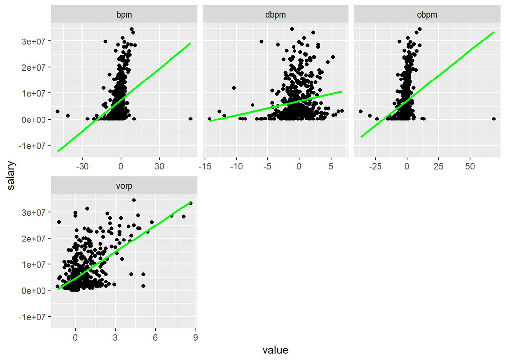

```r
#Representaciones graficas

nba_data %>%
  select_at(vars(-c("player","nba_country","tm"))) %>%
  tidyr::gather("id", "value", 22:25) %>%
  ggplot(., aes(y=salary, x=value))+
  geom_point()+
  geom_smooth(method = "lm", se=FALSE, color="green")+
  facet_wrap(~id,ncol= 3 ,scales="free_x")
```

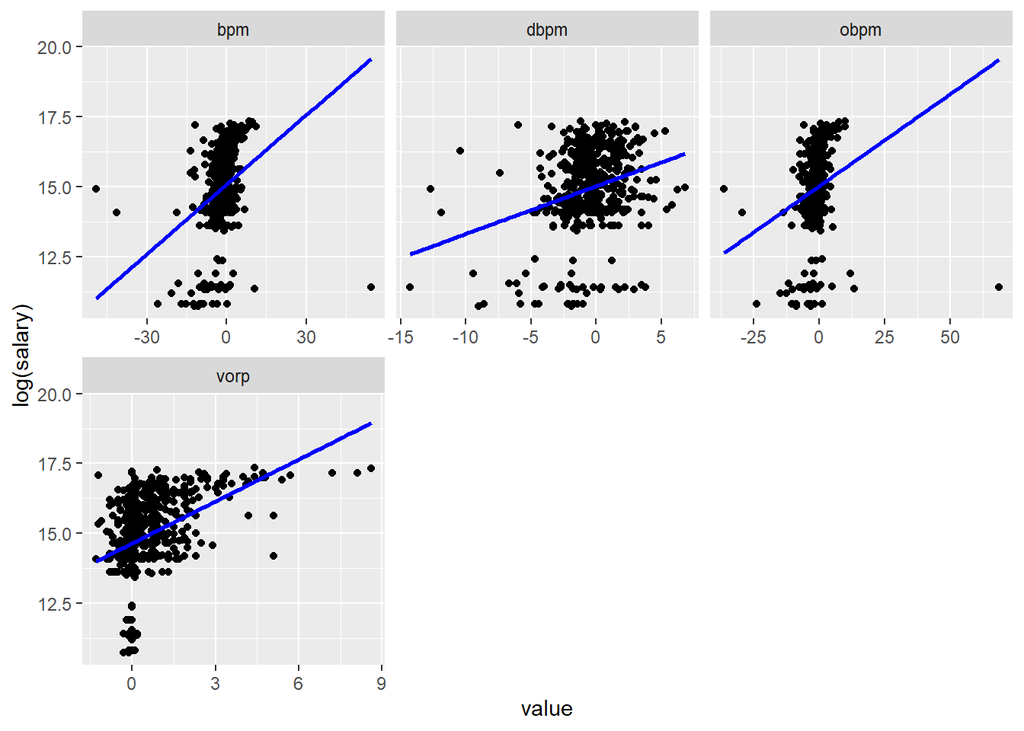

```r
#Aqui vamos a poner el logaritmico que nos vendra mejor

nba_data %>%
  select_at(vars(-c("player","nba_country","tm"))) %>%
  tidyr::gather("id", "value", 22:25) %>%
  ggplot(., aes(y=log(salary), x=value))+
  geom_point()+
  geom_smooth(method = "lm", se=FALSE, color="blue")+
  facet_wrap(~id,ncol=3 ,scales="free_x")
```

Apreciamos que en el salario se ven mejor las variables por lo que cambiaremos a log y trabajaremos con ello

```r
log_data_nba <- nba_data %>% mutate(salary = log(salary))
```

#seleccionamos las variables que queremos omitir

```r
no_vars <- c("player", "nba_country", "tm")
```

#un grafico de correlaciones nos ayuda a tener una vision mas detallada de lo que vamos a generar #y comparamos las distintas variables de una manera grafica

```
## Note: Using an external vector in selections is ambiguous.
## i Use `all_of(no_vars)` instead of `no_vars` to silence this message.
## i See <https://tidyselect.r-lib.org/reference/faq-external-vector.html>.
```

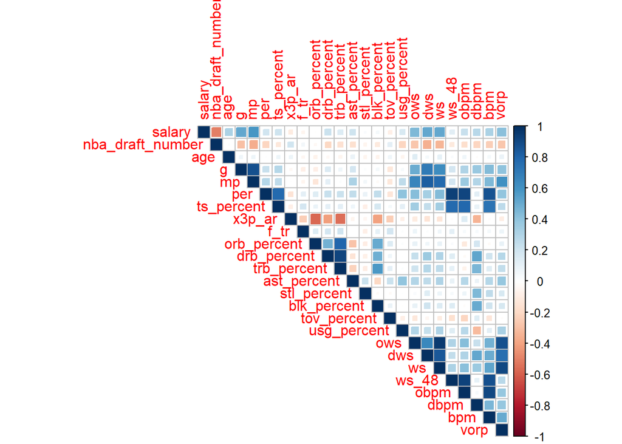

```r
corrplot(cor(log_data_nba%>%
              select_at(vars(-no_vars)),
            use = "complete.obs"),
         method = "square", type = "upper")
```

#mapa de calor, siempre muy intuitivo.

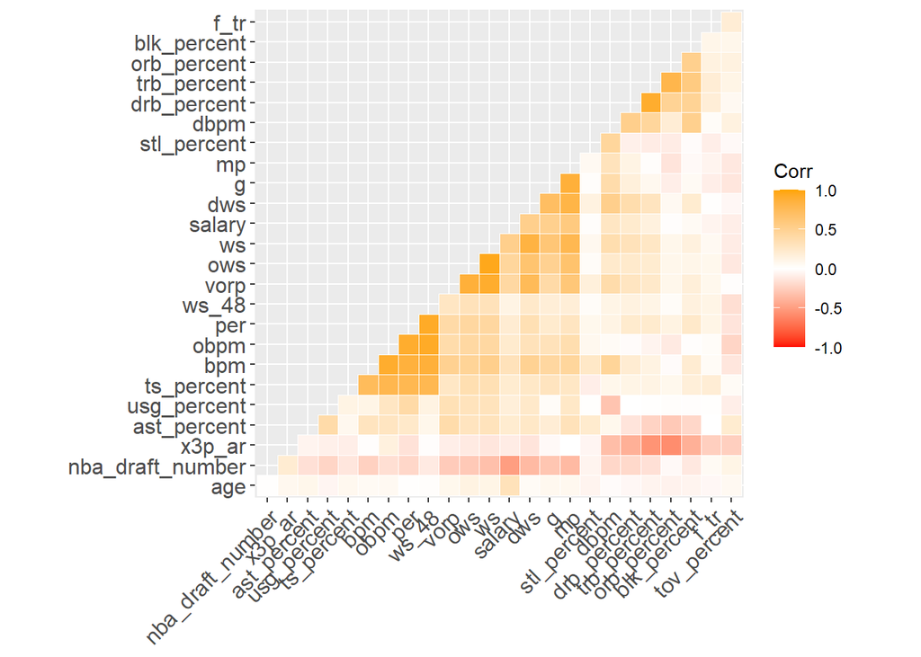

```r
ggcorrplot(cor(log_data_nba %>%
                   select_at(vars(-no_vars)),
                  use = "complete.obs"),
           hc.order = TRUE,
                type = "lower",
                outline.color = "white",
                ggtheme = ggplot2::theme_gray,
               colors = c("red", "white", "orange"))
```

Elastic Net Method

Generamos un espacio aleatorio para nuestro modelo

```r
log_data_nba <- log_data_nba %>%
  select_at(vars(-no_vars))
```

```r
set.seed(1984) #la actualidad me recuerda a esa novela

nba_split <- initial_split(log_data_nba, prop = 0.7, strata = "salary")
```

Seleccionamos la parte de testeo y de training

```r
nba_training <- training(nba_split) #entrenamiento, siempre mas grande que muestra
nba_testing  <- testing(nba_split) #testeo
```

No intercepto, lo vamos a eliminar, discriminamos el intercepto

```r
nba_training_x <- model.matrix(salary ~ ., data = nba_training)[, -1]
nba_training_y <- nba_training$salary

nba_testing_x <- model.matrix(salary ~ ., data = nba_testing)[, -1]
nba_testing_y <- nba_testing$salary

dim(nba_training) #nos cercioramos de que el numero de filas es el 70 por cien del total
```

```
## [1] 339  25
```

## Aplicacion del metodo Elastic Net

Definimos los tres modelos, el elastic es un intermedio entre el cresta y el lasso

```r
lasso_1   <- glmnet(nba_training_x, nba_training_y, alpha = 1.0)
elastic_1 <- glmnet(nba_training_x, nba_training_y, alpha = 0.5)
ridge_1    <- glmnet(nba_training_x, nba_training_y, alpha = 0.0)
```

#los ploteamos para la intepretacion visual

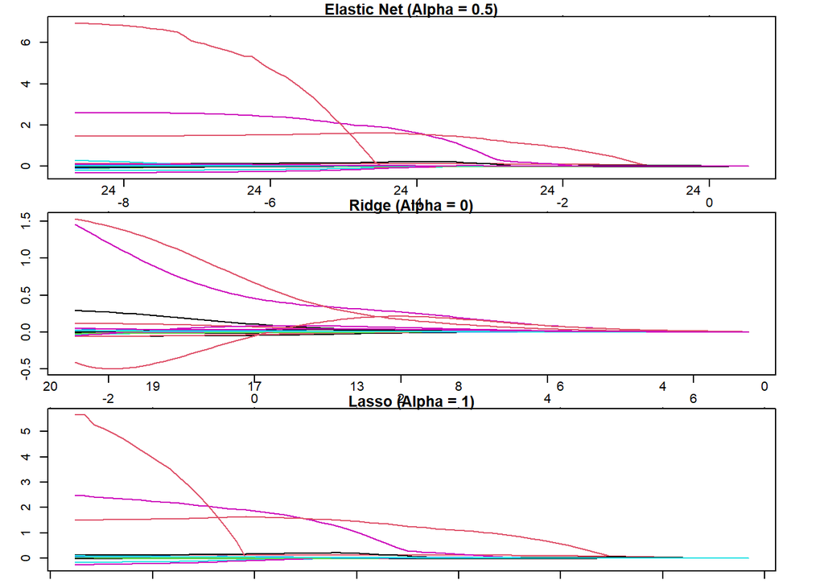

```r
par(mfrow = c(3, 1), mar = c(1, 3, 1, 3) + 0.1)

plot(elastic_1, xvar = "lambda", main = "Elastic Net (Alpha = 0.5)")
plot(ridge_1, xvar = "lambda", main = "Ridge (Alpha = 0)")
plot(lasso_1, xvar = "lambda", main = "Lasso (Alpha = 1)")
```

Para saber con que modelo nos quedamos tenemos que experimentar con la variacion de los parametros alfa y lambda

```r
fold_id <- sample(1:10, size = length(nba_training_y), replace = TRUE)
```

```r
tuning_grid <- tibble::tibble(
  alpha      = seq(0, 1, by = .1),
  mse_min    = NA,
  mse_1se    = NA,
  lambda_min = NA,
  lambda_1se = NA
)
tuning_grid
```

```
## # A tibble: 11 x 5
##    alpha mse_min mse_1se lambda_min lambda_1se
##    <dbl> <lgl>   <lgl>   <lgl>      <lgl>
##  1   0   NA      NA      NA         NA
##  2   0.1 NA      NA      NA         NA
##  3   0.2 NA      NA      NA         NA
##  4   0.3 NA      NA      NA         NA
##  5   0.4 NA      NA      NA         NA
##  6   0.5 NA      NA      NA         NA
##  7   0.6 NA      NA      NA         NA
##  8   0.7 NA      NA      NA         NA
##  9   0.8 NA      NA      NA         NA
## 10   0.9 NA      NA      NA         NA
## 11   1   NA      NA      NA         NA
```

loopeamos para completar la tabla que nos arroja anteriormente

```r
for(i in seq_along(tuning_grid$alpha)) {

  fit <- cv.glmnet(nba_training_x, nba_training_y, alpha = tuning_grid$alpha[i], foldid = fold_id)

# valores de alfa y lambda

  tuning_grid$mse_min[i]    <- fit$cvm[fit$lambda == fit$lambda.min]
  tuning_grid$mse_1se[i]    <- fit$cvm[fit$lambda == fit$lambda.1se]
  tuning_grid$lambda_min[i] <- fit$lambda.min
  tuning_grid$lambda_1se[i] <- fit$lambda.1se
}

tuning_grid
```

```
## # A tibble: 11 x 5
##    alpha mse_min mse_1se lambda_min lambda_1se
##    <dbl>   <dbl>   <dbl>      <dbl>      <dbl>
##  1   0      1.16    1.28     0.149       1.68
##  2   0.1    1.16    1.27     0.0895      1.01
##  3   0.2    1.14    1.27     0.198       0.730
##  4   0.3    1.13    1.25     0.159       0.534
##  5   0.4    1.12    1.25     0.119       0.439
##  6   0.5    1.12    1.24     0.105       0.352
##  7   0.6    1.12    1.25     0.0874      0.322
##  8   0.7    1.11    1.24     0.0749      0.276
##  9   0.8    1.11    1.23     0.0656      0.241
## 10   0.9    1.11    1.24     0.0583      0.235
## 11   1      1.11    1.24     0.0524      0.212
```

Vemos en la parte superior lo datos cargados en la tabla

Vemos que el alfa es el optimo, veremos como predice el modelo

Pasamos a plotearlos

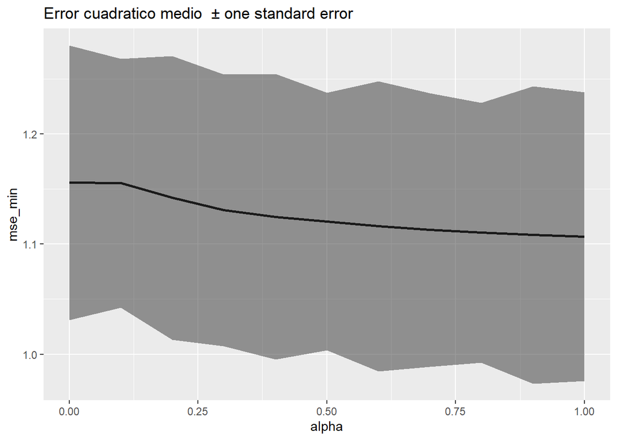

```r
tuning_grid %>%
  mutate(se = mse_1se - mse_min) %>%
  ggplot(aes(alpha, mse_min)) +
  geom_line(size = 1) +
  geom_ribbon(aes(ymax = mse_min + se, ymin = mse_min - se), alpha = .5) +
  ggtitle("Error cuadratico medio  ± one standard error")
```

La grafica muestra nuestra linea dentro de las barras laterales por ende asumimos validez

## prediccion

Vamos a usar el modelo lasso para predecir

```r
# Calculamos el mínimo MSE para Lasso
crossva_Lasso   <- cv.glmnet(nba_training_x, nba_training_y, alpha = 1.0)
min(crossva_Lasso$cvm)
```

```
## [1] 1.14251
```

```r
# Realizamos el cálculo con el dataset de training

prediccion <- predict(crossva_Lasso, s=crossva_Lasso$lambda.min, nba_testing_x)
mean((nba_testing_y - prediccion)^2)
```

```
## [1] 1.529892
```

De media del testeo menos la prediccion al cuadrado nos da 1.53, ya partimos de la base de que el laso era el mejor modelo.